# Arabidopsis aphid project - checking expression of key genes in WT

Nicolas Delhomme

2017-10-16

# 1 Setup

Set the working dir

```r
setwd("/mnt/picea/projects/arabidopsis/mschmid/porcupine-RNA-Seq/analysis/kallisto")
```

Gene list

```r
goi <- c("AT1G21250","AT1G15580","AT3G23240")
```

Data

```r
dat <- read.csv("combined-library-size-normalized_variance-stabilized_gene-expression_data.csv",
                row.names=1,as.is=TRUE)
```

Sample info

```r
samples <- read.csv("~/Git/UPSCb/projects/arabidopsis-porcupine-RNA-Seq/doc/RNA-seq_pcp_vs_Col-0_info.csv")
```

WT samples

```r
smpl.sel <- paste0("X",samples$SampleID[grep("Col-0",samples$Description)])
```

# 2 Rationale

Before performing a HTS experiment, we aim to look up the expression levels of a few genes of interest to decide on an adequate sequencing depth.

# 3 Screen

## 3.1 Boxplot

Two of the gene of interest appear rather lowly expressed, their expression is however, fairly invariable.

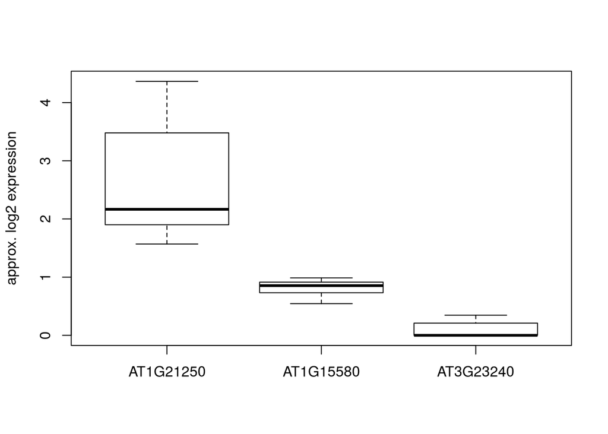

```r
boxplot(t(dat[goi,smpl.sel]),
        ylab="approx. log2 expression")
```

## 3.2 Density

Here we can clearly see that two genes are on the lower end of the peak of expression of most genes. One being very close to these genes that are only stochastically expressed (i.e. “biological noise”)

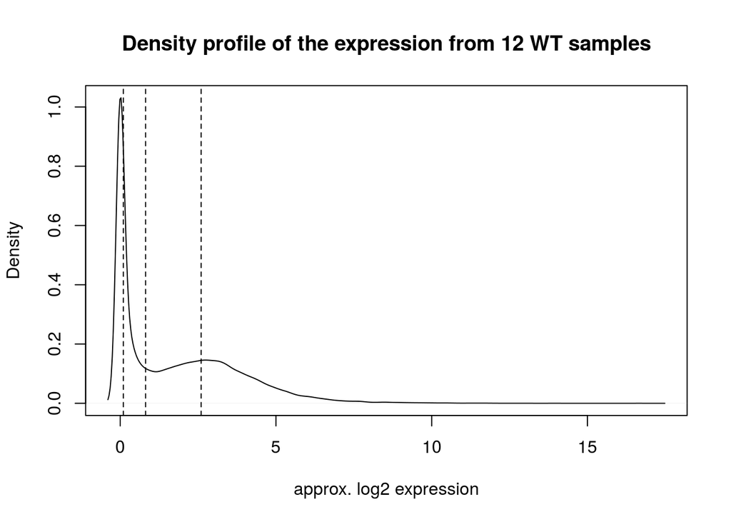

```r
plot(density(as.matrix(dat[,smpl.sel])),main="Density profile of the expression from 12 WT samples",
     xlab="approx. log2 expression")

abline(v=rowMeans(dat[goi,smpl.sel]),lty=2)
```

# 4 Conclusion

These findings suggest that since these genes are of interest, it would be counter-productive to restrict the sequencing depth, unless if the expected changes in expression would be consequent. Given that under the studies design, we won’t be able to trust log2 fold change below 0.5, and given the variablity of the two lowly expressed genes, the relative expression increase (we would not be able to estimate a decrease) would have to be by at least a fold (+100%). If the expected effect is a decrease in expression, then sequencing deeper is unavoidable.